# a549_rnaseq

Rakesh Santhanam

9 July 2020

# SARScov2 and RSV Rnaseq analysis

Cell line used: **A549** cell line- adenocarcinomic human alveolar basal epithelial cells

Virus: **SARScov2** and **RSV**- Respiratory-syncytial-virus.

Metadata loading for SARScov2 and RSV virus.

Throughout this analysis we will do sars_cov2 followed by rsv virus analysis

```r
metadata_a549_cell_sars_cov2 <-
  read_csv("~/rnaseq/a549_cells/metadata_a549_cell_sars_cov2.csv")
metadata_a549_cell_rsv <-
  read_csv("~/rnaseq/a549_cells/metadata_a549_cell_rsv.csv")
```

quant files for tximport

```r
sars_cov2_quant_files <-
  paste0(metadata_a549_cell_sars_cov2$samples,"/quant.sf" )

names(sars_cov2_quant_files) <- metadata_a549_cell_sars_cov2$samples

rsv_quant_files <-
  paste0(metadata_a549_cell_rsv$samples,"/quant.sf" )

names(rsv_quant_files) <- metadata_a549_cell_rsv$samples
```

gene map file constructed from gencode transcript files (see bash scripts)

```r
gene_map <-
  read_csv("~/rnaseq/gene_map.csv", col_names = c("enstid", "ensgid"))
sars_cov2_count_data <-
  tximport(files = sars_cov2_quant_files, ## quant_files should have names for columns
           type = "salmon",
           tx2gene =gene_map,
           ignoreTxVersion = TRUE )
```

```
## reading in files with read_tsv
```

```
## 1 2 3 4 5 6
## removing duplicated transcript rows from tx2gene
## summarizing abundance
## summarizing counts
## summarizing length
```

```r
rsv_count_data <-
  tximport(files = rsv_quant_files, ## quant_files should have names for columns
           type = "salmon",
           tx2gene =gene_map,
           ignoreTxVersion = TRUE )
```

```
## reading in files with read_tsv
## 1 2 3 4 5 6
## removing duplicated transcript rows from tx2gene
## summarizing abundance
## summarizing counts
## summarizing length
```

```r
metadata_a549_cell_sars_cov2$conditions <-
  factor(metadata_a549_cell_sars_cov2$conditions,
         levels = c("mock", "sars_cov2"))

metadata_a549_cell_sars_cov2$conditions
```

```
## [1] mock      mock      mock      sars_cov2 sars_cov2 sars_cov2
## Levels: mock sars_cov2
```

```r
metadata_a549_cell_rsv$conditions <-
  factor(metadata_a549_cell_rsv$conditions,
         levels = c("mock", "RSV"))

metadata_a549_cell_rsv$conditions
```

```
## [1] mock mock mock RSV  RSV  RSV
## Levels: mock RSV
```

converting tximport to deseqdataset for stat

```r
sars_covs_deseq_dataset_a549 <-
  DESeqDataSetFromTximport(txi = sars_cov2_count_data,
                           colData = metadata_a549_cell_sars_cov2, ## sample table
                           design = ~conditions) ## conditions like treatment or control
```

```
## using counts and average transcript lengths from tximport
```

```r
rsv_deseq_dataset_a549 <-
  DESeqDataSetFromTximport(txi = rsv_count_data,
                           colData = metadata_a549_cell_rsv, ## sample table
                           design = ~conditions) ## conditions like treatment or control
```

```
## using counts and average transcript lengths from tximport
```

Basically DEseq2 caries out three steps for data normalizaton 1. EstimateSizeFacors 2. EstimateDispersions 3. Nbinomwald test

```r
sars_cov2_deseq_normalized_stat <- DESeq(sars_covs_deseq_dataset_a549)
```

```
## using 'avgTxLength' from assays(dds), correcting for library size
```

```r
rsv_deseq_normalized_stat <- DESeq(rsv_deseq_dataset_a549)
```

```
## using 'avgTxLength' from assays(dds), correcting for library size
```

```r
sars_cov2_deseq_normalized_stat
```

```
## class: DESeqDataSet
## dim: 60624 6
## metadata(1): version
## assays(6): counts avgTxLength ... H cooks
## rownames(60624): ENSG00000000003 ENSG00000000005 ... ENSG00000288603
##   ENSG00000288604
## rowData names(22): baseMean baseVar ... deviance maxCooks
## colnames(6): GSM4462342 GSM4462343 ... GSM4462346 GSM4462347
## colData names(9): samples source_name ... time_points conditions
```

```r
names(assays(sars_cov2_deseq_normalized_stat)) ## contain 6 matrix
```

```
## [1] "counts"               "avgTxLength"          "normalizationFactors"
## [4] "mu"                   "H"                    "cooks"
```

```r
 ##  gives raw counts first in list
 ## gives
 ## gives normalizationFactors 3rd in list
```

sars_cov2_deseq_normalized_stat contains 6 matrix

```r
names(assays(sars_cov2_deseq_normalized_stat))
```

```
## [1] "counts"               "avgTxLength"          "normalizationFactors"
## [4] "mu"                   "H"                    "cooks"
```

raw counts first in list

```r
head(assays(sars_cov2_deseq_normalized_stat)[1][[1]])
```

```
##                 GSM4462342 GSM4462343 GSM4462344 GSM4462345 GSM4462346
## ENSG00000000003       1288        105        772        181         75
## ENSG00000000005          1          0          1          0          0
## ENSG00000000419        951         70        498        285         81
## ENSG00000000457        294         28        223        130         16
## ENSG00000000460         83         10         41         23          3
## ENSG00000000938          0          0          0          0          0
##                 GSM4462347
## ENSG00000000003         56
## ENSG00000000005          0
## ENSG00000000419         93
## ENSG00000000457         21
## ENSG00000000460          3
## ENSG00000000938          0
```

avgTxLength 2nd in list

```r
head(assays(sars_cov2_deseq_normalized_stat)[2][[1]])
```

```
##                 GSM4462342 GSM4462343 GSM4462344 GSM4462345 GSM4462346
## ENSG00000000003   2286.196   1846.375   2365.099  1987.5204  2517.9116
## ENSG00000000005    956.000    956.000    956.000   956.0000   956.0000
## ENSG00000000419    796.682    718.232    789.457   741.9986   832.1964
## ENSG00000000457   3310.105   3977.398   3308.173  4480.2456  3324.2726
## ENSG00000000460   2082.606   1715.634   2157.160  2497.9552   759.8471
## ENSG00000000938   1473.143   1473.143   1473.143  1473.1429  1473.1429
##                 GSM4462347
## ENSG00000000003  1822.7995
## ENSG00000000005   956.0000
## ENSG00000000419   831.3082
## ENSG00000000457  5013.4535
## ENSG00000000460  2412.0000
## ENSG00000000938  1473.1429
```

normalizationFactors 3rd in list

```r
head(assays(sars_cov2_deseq_normalized_stat)[3][[1]])
```

```
##                 GSM4462342 GSM4462343 GSM4462344 GSM4462345 GSM4462346
## ENSG00000000003   5.171437  0.3990498   3.575899   1.159827  0.4301884
## ENSG00000000005   4.797999  0.4584262   3.206994   1.237781  0.3623936
## ENSG00000000419   4.876785  0.4200709   3.230094   1.171751  0.3847643
## ENSG00000000457   4.126114  0.4737048   2.756294   1.440737  0.3129798
## ENSG00000000460   5.517388  0.4342706   3.819854   1.707240  0.1520453
## ENSG00000000938   4.797999  0.4584262   3.206994   1.237781  0.3623936
##                 GSM4462347
## ENSG00000000003  0.2715968
## ENSG00000000005  0.3160443
## ENSG00000000419  0.3351958
## ENSG00000000457  0.4116463
## ENSG00000000460  0.4209123
## ENSG00000000938  0.3160443
```

Now PCA plot

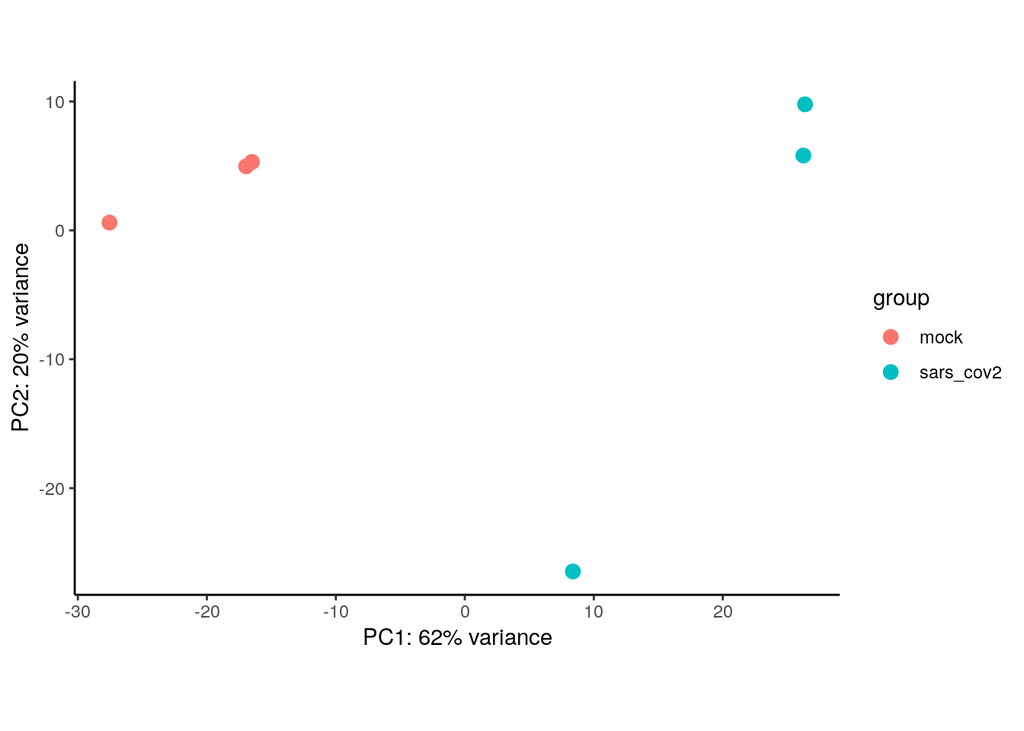

```r
sars_cov2_vst <-
  varianceStabilizingTransformation(sars_cov2_deseq_normalized_stat)

plotPCA(sars_cov2_vst, intgroup = 'conditions') +
  theme_classic()
```

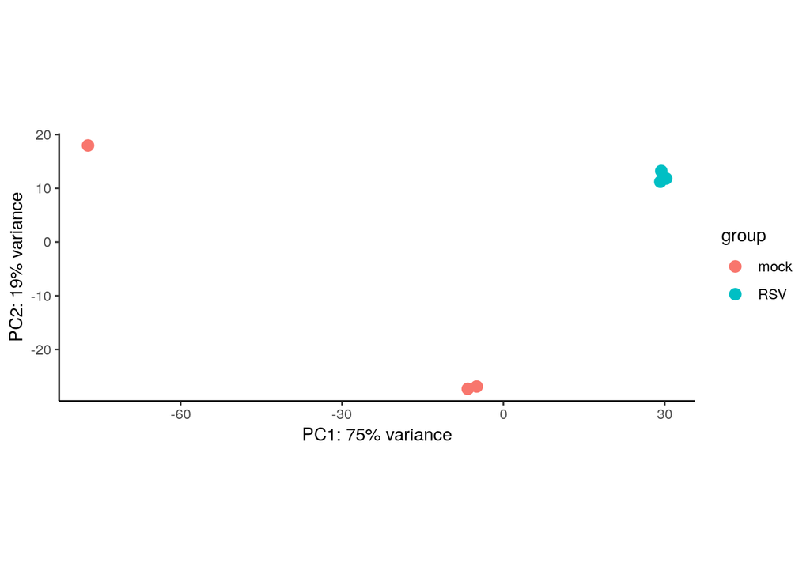

```r
rsv_vst <-
  varianceStabilizingTransformation(rsv_deseq_normalized_stat)

plotPCA(rsv_vst, intgroup = 'conditions')+
  theme_classic()
```

Differentially expressed genes

```r
sars_cov2_deg <-
  results(sars_cov2_deseq_normalized_stat)

rsv_deg <-
  results(rsv_deseq_normalized_stat)
```

summary of DEGs

```r
summary(sars_cov2_deg)
```

```
##
## out of 34396 with nonzero total read count
## adjusted p-value < 0.1
## LFC > 0 (up)       : 1840, 5.3%
## LFC < 0 (down)     : 1431, 4.2%
## outliers [1]       : 4, 0.012%
## low counts [2]     : 16642, 48%
## (mean count < 2)
## [1] see 'cooksCutoff' argument of ?results
## [2] see 'independentFiltering' argument of ?results
```

```r
summary(rsv_deg)
```

```
##
## out of 33494 with nonzero total read count
## adjusted p-value < 0.1
## LFC > 0 (up)       : 1195, 3.6%
## LFC < 0 (down)     : 1318, 3.9%
## outliers [1]       : 168, 0.5%
## low counts [2]     : 15542, 46%
## (mean count < 3)
## [1] see 'cooksCutoff' argument of ?results
## [2] see 'independentFiltering' argument of ?results
```

```r
names(sars_cov2_deg)
```

```
## [1] "baseMean"       "log2FoldChange" "lfcSE"          "stat"
## [5] "pvalue"         "padj"
```

```r
## baseMean - mean of gene on entier experiment
## log2foldchange - treated/mock
## lfcSE- standard error
## stat - wald test - specifically for negative binomial distribution
## pvalue and padj values
```

MA plot 1. red dots are differentially expressed genes

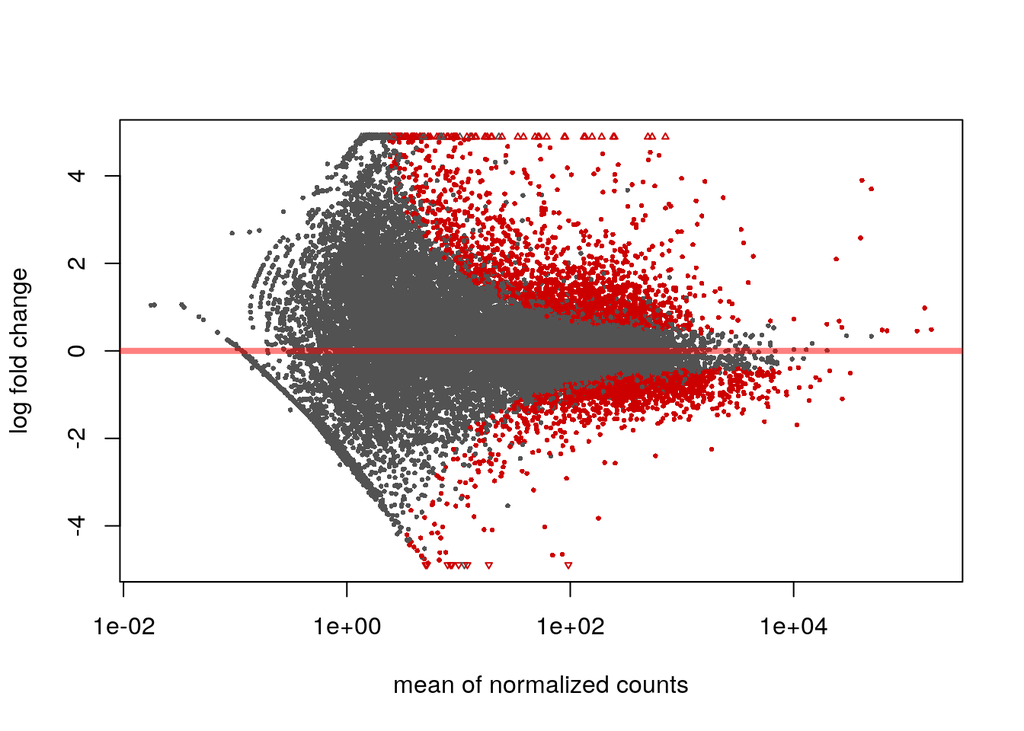

```r
plotMA(sars_cov2_deg)
```

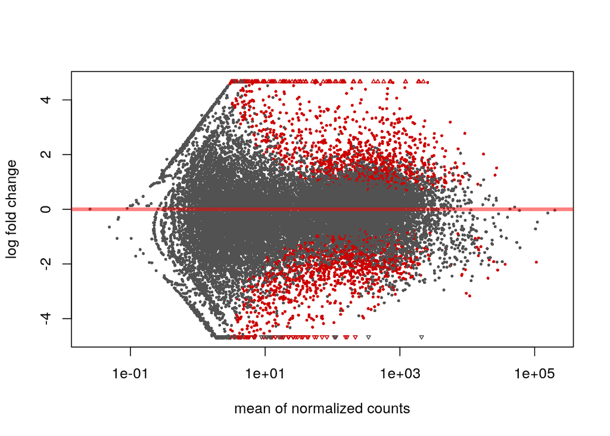

```r
plotMA(rsv_deg)
```

Removing na and converting to tibble

```r
sars_cov2_deg_tibble <-
  sars_cov2_deg %>%
  as.data.frame() %>%
  rownames_to_column(.) %>%
  as_tibble() %>%
  drop_na()

rsv_deg_tibble <-
  rsv_deg %>%
   as.data.frame() %>%
  rownames_to_column(.) %>%
  as_tibble() %>%
  drop_na()
```

Filtering choices 1. logfold change >1 < -1 1. padj < 0.05

```r
sars_cov2_result_filtered <- ## based on padj and log2FoldChange
  sars_cov2_deg_tibble %>%
  dplyr::filter(padj < 0.05) %>%
  dplyr::filter(log2FoldChange > 1 | log2FoldChange < -1)

head(sars_cov2_result_filtered)
```

```
## # A tibble: 6 x 7
##   rowname         baseMean log2FoldChange lfcSE  stat   pvalue         padj
##   <chr>              <dbl>          <dbl> <dbl> <dbl>    <dbl>        <dbl>
## 1 ENSG00000001630    357.           -1.02 0.208 -4.93 8.23e- 7 0.0000305
## 2 ENSG00000003400     71.2           1.55 0.361  4.30 1.74e- 5 0.000440
## 3 ENSG00000003989    186.            1.35 0.267  5.05 4.52e- 7 0.0000182
## 4 ENSG00000005007    356.            1.03 0.245  4.22 2.46e- 5 0.000586
## 5 ENSG00000005483    379.            1.36 0.299  4.56 5.10e- 6 0.000150
## 6 ENSG00000005884   2310.           -1.21 0.192 -6.32 2.70e-10 0.0000000262
```

```r
rsv_result_filtered <-
  rsv_deg_tibble %>%
  dplyr::filter(padj < 0.05) %>%
  dplyr::filter(log2FoldChange > 1 | log2FoldChange < -1)

head(rsv_result_filtered)
```

```
## # A tibble: 6 x 7
##   rowname         baseMean log2FoldChange lfcSE  stat   pvalue          padj
##   <chr>              <dbl>          <dbl> <dbl> <dbl>    <dbl>         <dbl>
## 1 ENSG00000002549    850.            2.47 0.360  6.86 6.86e-12 0.00000000133
## 2 ENSG00000003400    161.            1.59 0.394  4.04 5.24e- 5 0.00175
## 3 ENSG00000004399    510.           -1.75 0.605 -2.89 3.87e- 3 0.0436
## 4 ENSG00000004468    236.            1.78 0.494  3.60 3.14e- 4 0.00724
## 5 ENSG00000004660    157.           -1.58 0.376 -4.19 2.73e- 5 0.00103
## 6 ENSG00000004848     71.0          -4.00 1.12  -3.57 3.52e- 4 0.00787
```

After filtering sanity check is important

```r
max(sars_cov2_result_filtered$padj) < 0.05 ## TRUE
```

```
## [1] TRUE
```

```r
max(rsv_result_filtered$padj) < 0.05 ### TRUE
```

```
## [1] TRUE
```

Volcano plot

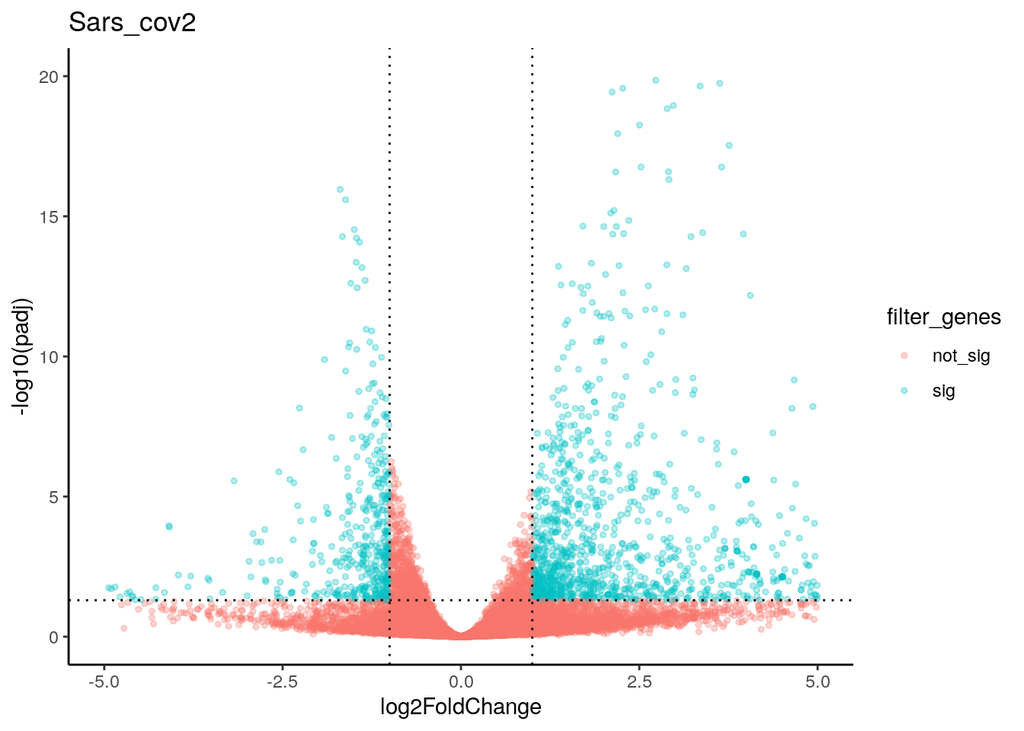

```r
sars_cov2_volcano_plot <-
  sars_cov2_deg_tibble %>%
  dplyr::mutate(filter_genes = .$rowname) %>%
dplyr::mutate(filter_genes = ifelse(.$filter_genes %in% sars_cov2_result_filtered$rowname, "sig", "not_sig")) %>% ## changing filter genes to sig and not_sig
  #dplyr::filter(filter_genes == "sig")
  ## dplyr::arrange(padj) sanity check - fine
  ggplot(aes(x = log2FoldChange, y = -log10(padj))) +
  #scale_colour_manual(values = c("black", "red")) +
  geom_point(aes(colour = filter_genes), size =1, alpha = 0.3)+
  geom_vline(xintercept = 1, linetype = 3) +
  geom_vline(xintercept = -1, linetype = 3) +
  geom_hline(yintercept = -log10(0.05), linetype =3) +
  xlim(-5,5)+
  ylim(0,20)+
  theme(legend.position ="none") +
  theme_classic() +
  ggtitle("Sars_cov2")

sars_cov2_volcano_plot
```

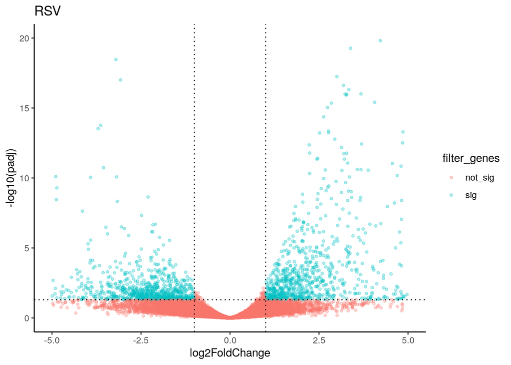

```r
rsv_volcano_plot <-
  rsv_deg_tibble %>%
  dplyr::mutate(filter_genes = .$rowname) %>%
  dplyr::mutate(filter_genes = ifelse(.$filter_genes %in% rsv_result_filtered$rowname, "sig", "not_sig")) %>% ## changing filter genes to sig and not_sig
  #dplyr::filter(filter_genes == "sig")
  ## dplyr::arrange(padj) sanity check - fine
  ggplot(aes(x = log2FoldChange, y = -log10(padj))) +
  #scale_colour_manual(values = c("black", "red")) +
  geom_point(aes(colour = filter_genes), size =1, alpha = 0.3)+
  geom_vline(xintercept = 1, linetype = 3) +
  geom_vline(xintercept = -1, linetype = 3) +
  geom_hline(yintercept = -log10(0.05), linetype =3) +
  xlim(-5,5)+
  ylim(0,20)+
  theme(legend.position ="none") +
  theme_classic() +
  ggtitle("RSV")

rsv_volcano_plot
```

Now from DEGs to gene annotation

```r
listMarts()
```

```
##                biomart                version
## 1 ENSEMBL_MART_ENSEMBL      Ensembl Genes 100
## 2   ENSEMBL_MART_MOUSE      Mouse strains 100
## 3     ENSEMBL_MART_SNP  Ensembl Variation 100
## 4 ENSEMBL_MART_FUNCGEN Ensembl Regulation 100
```

```r
ensembl_100 <-
  useEnsembl("ensembl") ## using default version 100 otherwise need to specify needed version

ensembl_100_human <-
  useDataset("hsapiens_gene_ensembl", mart = ensembl_100) ## loading human ensamble

ensembl_100_human
```

```
## Object of class 'Mart':
##   Using the ENSEMBL_MART_ENSEMBL BioMart database
##   Using the hsapiens_gene_ensembl dataset
```

```r
head(listDatasets(ensembl_100))
```

```
##                      dataset                                  description
## 1   acalliptera_gene_ensembl             Eastern happy genes (fAstCal1.2)
## 2 acarolinensis_gene_ensembl               Anole lizard genes (AnoCar2.0)
## 3  acchrysaetos_gene_ensembl              Golden eagle genes (bAquChr1.2)
## 4  acitrinellus_gene_ensembl               Midas cichlid genes (Midas_v5)
## 5  amelanoleuca_gene_ensembl                        Panda genes (ailMel1)
## 6    amexicanus_gene_ensembl Mexican tetra genes (Astyanax_mexicanus-2.0)
##                  version
## 1             fAstCal1.2
## 2              AnoCar2.0
## 3             bAquChr1.2
## 4               Midas_v5
## 5                ailMel1
## 6 Astyanax_mexicanus-2.0
```

```r
head(listAttributes(ensembl_100_human)) ## list all attributes avaialble for ensembl_100_human
```

```
##                            name                  description         page
## 1               ensembl_gene_id               Gene stable ID feature_page
## 2       ensembl_gene_id_version       Gene stable ID version feature_page
## 3         ensembl_transcript_id         Transcript stable ID feature_page
## 4 ensembl_transcript_id_version Transcript stable ID version feature_page
## 5            ensembl_peptide_id            Protein stable ID feature_page
## 6    ensembl_peptide_id_version    Protein stable ID version feature_page
```

```r
head(listFilters(ensembl_100_human)) ## list all filters avaialble for ensembl_100_human
```

```
##                 name                            description
## 1    chromosome_name               Chromosome/scaffold name
## 2              start                                  Start
## 3                end                                    End
## 4             strand                                 Strand
## 5 chromosomal_region e.g. 1:100:10000:-1, 1:100000:200000:1
## 6          with_ccds                        With CCDS ID(s)
```

```r
annotation_sars_cov2_result <-
  getBM(attributes = c("ensembl_gene_id", "chromosome_name",
                       "start_position", "end_position",
                       "strand", "gene_biotype", "external_gene_name", "description"),
        filters = c("ensembl_gene_id"),
        values = sars_cov2_deg_tibble$rowname, ## used in valcano plot- including all genes
        mart = ensembl_100_human)

head(annotation_sars_cov2_result)
```

```
##   ensembl_gene_id chromosome_name start_position end_position strand
## 1 ENSG00000000003               X      100627108    100639991     -1
## 2 ENSG00000000419              20       50934867     50958555     -1
## 3 ENSG00000000457               1      169849631    169894267     -1
## 4 ENSG00000000460               1      169662007    169854080      1
## 5 ENSG00000000971               1      196652043    196747504      1
## 6 ENSG00000001036               6      143494812    143511720     -1
##     gene_biotype external_gene_name
## 1 protein_coding             TSPAN6
## 2 protein_coding               DPM1
## 3 protein_coding              SCYL3
## 4 protein_coding           C1orf112
## 5 protein_coding                CFH
## 6 protein_coding              FUCA2
##                                                                                      description
## 1                                              tetraspanin 6 [Source:HGNC Symbol;Acc:HGNC:11858]
## 2 dolichyl-phosphate mannosyltransferase subunit 1, catalytic [Source:HGNC Symbol;Acc:HGNC:3005]
## 3                                   SCY1 like pseudokinase 3 [Source:HGNC Symbol;Acc:HGNC:19285]
## 4                        chromosome 1 open reading frame 112 [Source:HGNC Symbol;Acc:HGNC:25565]
## 5                                         complement factor H [Source:HGNC Symbol;Acc:HGNC:4883]
## 6                                        alpha-L-fucosidase 2 [Source:HGNC Symbol;Acc:HGNC:4008]
```

```r
annotation_rsv_result <-
  getBM(attributes = c("ensembl_gene_id", "chromosome_name",
                       "start_position", "end_position",
                       "strand", "gene_biotype", "external_gene_name", "description"),
        filters = c("ensembl_gene_id"),
        values = rsv_deg_tibble$rowname, ## used in valcano plot- including all genes
        mart = ensembl_100_human)

head(annotation_rsv_result)
```

```
##   ensembl_gene_id chromosome_name start_position end_position strand
## 1 ENSG00000000003               X      100627108    100639991     -1
## 2 ENSG00000000419              20       50934867     50958555     -1
## 3 ENSG00000000457               1      169849631    169894267     -1
## 4 ENSG00000000460               1      169662007    169854080      1
## 5 ENSG00000000971               1      196652043    196747504      1
## 6 ENSG00000001036               6      143494812    143511720     -1
##     gene_biotype external_gene_name
## 1 protein_coding             TSPAN6
## 2 protein_coding               DPM1
## 3 protein_coding              SCYL3
## 4 protein_coding           C1orf112
## 5 protein_coding                CFH
## 6 protein_coding              FUCA2
##                                                                                      description
## 1                                              tetraspanin 6 [Source:HGNC Symbol;Acc:HGNC:11858]
## 2 dolichyl-phosphate mannosyltransferase subunit 1, catalytic [Source:HGNC Symbol;Acc:HGNC:3005]
## 3                                   SCY1 like pseudokinase 3 [Source:HGNC Symbol;Acc:HGNC:19285]
## 4                        chromosome 1 open reading frame 112 [Source:HGNC Symbol;Acc:HGNC:25565]
## 5                                         complement factor H [Source:HGNC Symbol;Acc:HGNC:4883]
## 6                                        alpha-L-fucosidase 2 [Source:HGNC Symbol;Acc:HGNC:4008]
```

```r
length(sars_cov2_deg_tibble$rowname) == nrow(annotation_sars_cov2_result) ## true so its fine
```

```
## [1] TRUE
```

```r
length(rsv_deg_tibble$rowname) == nrow(annotation_rsv_result) ## true so its fine
```

```
## [1] TRUE
```

Joining degs tables with annotation table

```r
sars_cov2_annotation_result <- ## joinging annotation and result tables
  inner_join(sars_cov2_deg_tibble, tibble(annotation_sars_cov2_result),
             by = c("rowname"= "ensembl_gene_id"))

head(sars_cov2_annotation_result)
```

```
## # A tibble: 6 x 14
##   rowname baseMean log2FoldChange lfcSE   stat  pvalue   padj chromosome_name
##   <chr>      <dbl>          <dbl> <dbl>  <dbl>   <dbl>  <dbl> <chr>
## 1 ENSG00…    211.         -0.454  0.245 -1.85  0.0643  0.231  X
## 2 ENSG00…    208.          0.496  0.246  2.02  0.0438  0.180  20
## 3 ENSG00…     67.3        -0.0954 0.380 -0.251 0.802   0.916  1
## 4 ENSG00…     14.9        -0.294  0.688 -0.427 0.669   0.856  1
## 5 ENSG00…   1040.          0.199  0.179  1.11  0.266   0.548  1
## 6 ENSG00…    245.         -0.754  0.291 -2.59  0.00964 0.0627 6
## # … with 6 more variables: start_position <int>, end_position <int>,
## #   strand <int>, gene_biotype <chr>, external_gene_name <chr>,
## #   description <chr>
```

```r
rsv_annotation_result <- ## joinging annotation and result tables
  inner_join(rsv_deg_tibble, tibble(annotation_rsv_result),
             by = c("rowname"= "ensembl_gene_id"))

head(rsv_annotation_result)
```

```
## # A tibble: 6 x 14
##   rowname baseMean log2FoldChange lfcSE    stat pvalue  padj chromosome_name
##   <chr>      <dbl>          <dbl> <dbl>   <dbl>  <dbl> <dbl> <chr>
## 1 ENSG00…    283.         0.294   0.502  0.585   0.558 0.755 X
## 2 ENSG00…    318.         0.535   0.404  1.32    0.186 0.423 20
## 3 ENSG00…     92.3        0.462   0.510  0.906   0.365 0.605 1
## 4 ENSG00…    151.        -0.338   0.338 -1.00    0.317 0.560 1
## 5 ENSG00…    310.         0.248   0.558  0.445   0.657 0.815 1
## 6 ENSG00…    624.         0.00781 0.271  0.0288  0.977 0.988 6
## # … with 6 more variables: start_position <int>, end_position <int>,
## #   strand <int>, gene_biotype <chr>, external_gene_name <chr>,
## #   description <chr>
```

Annotation files with only significant genes

```r
sars_cov2_result_deg <-
  sars_cov2_annotation_result %>%
  dplyr::filter(rowname %in% sars_cov2_result_filtered$rowname) #%>%  ## filtering deg genes based on cutoff - 1 fold difference and padj 0,05

head(sars_cov2_result_deg)
```

```
## # A tibble: 6 x 14
##   rowname baseMean log2FoldChange lfcSE  stat   pvalue    padj chromosome_name
##   <chr>      <dbl>          <dbl> <dbl> <dbl>    <dbl>   <dbl> <chr>
## 1 ENSG00…    357.           -1.02 0.208 -4.93 8.23e- 7 3.05e-5 7
## 2 ENSG00…     71.2           1.55 0.361  4.30 1.74e- 5 4.40e-4 2
## 3 ENSG00…    186.            1.35 0.267  5.05 4.52e- 7 1.82e-5 8
## 4 ENSG00…    356.            1.03 0.245  4.22 2.46e- 5 5.86e-4 19
## 5 ENSG00…    379.            1.36 0.299  4.56 5.10e- 6 1.50e-4 7
## 6 ENSG00…   2310.           -1.21 0.192 -6.32 2.70e-10 2.62e-8 17
## # … with 6 more variables: start_position <int>, end_position <int>,
## #   strand <int>, gene_biotype <chr>, external_gene_name <chr>,
## #   description <chr>
```

```r
rsv_result_deg <-
  rsv_annotation_result %>%
  dplyr::filter(rowname %in% rsv_result_filtered$rowname) #%>%  ## filtering deg genes based on cutoff - 1 fold difference and padj 0,05

head(rsv_result_deg)
```

```
## # A tibble: 6 x 14
##   rowname baseMean log2FoldChange lfcSE  stat   pvalue    padj chromosome_name
##   <chr>      <dbl>          <dbl> <dbl> <dbl>    <dbl>   <dbl> <chr>
## 1 ENSG00…    850.            2.47 0.360  6.86 6.86e-12 1.33e-9 4
## 2 ENSG00…    161.            1.59 0.394  4.04 5.24e- 5 1.75e-3 2
## 3 ENSG00…    510.           -1.75 0.605 -2.89 3.87e- 3 4.36e-2 3
## 4 ENSG00…    236.            1.78 0.494  3.60 3.14e- 4 7.24e-3 4
## 5 ENSG00…    157.           -1.58 0.376 -4.19 2.73e- 5 1.03e-3 17
## 6 ENSG00…     71.0          -4.00 1.12  -3.57 3.52e- 4 7.87e-3 X
## # … with 6 more variables: start_position <int>, end_position <int>,
## #   strand <int>, gene_biotype <chr>, external_gene_name <chr>,
## #   description <chr>
```

Saving files

```r
write_csv(sars_cov2_result_deg, "~/rnaseq/a549_cells/sars_cov2_result_deg.csv")

write_csv(rsv_result_deg, "~/rnaseq/a549_cells/rsv_result_deg.csv")
```

Overlap DEGS between sars_cov2 and rsv

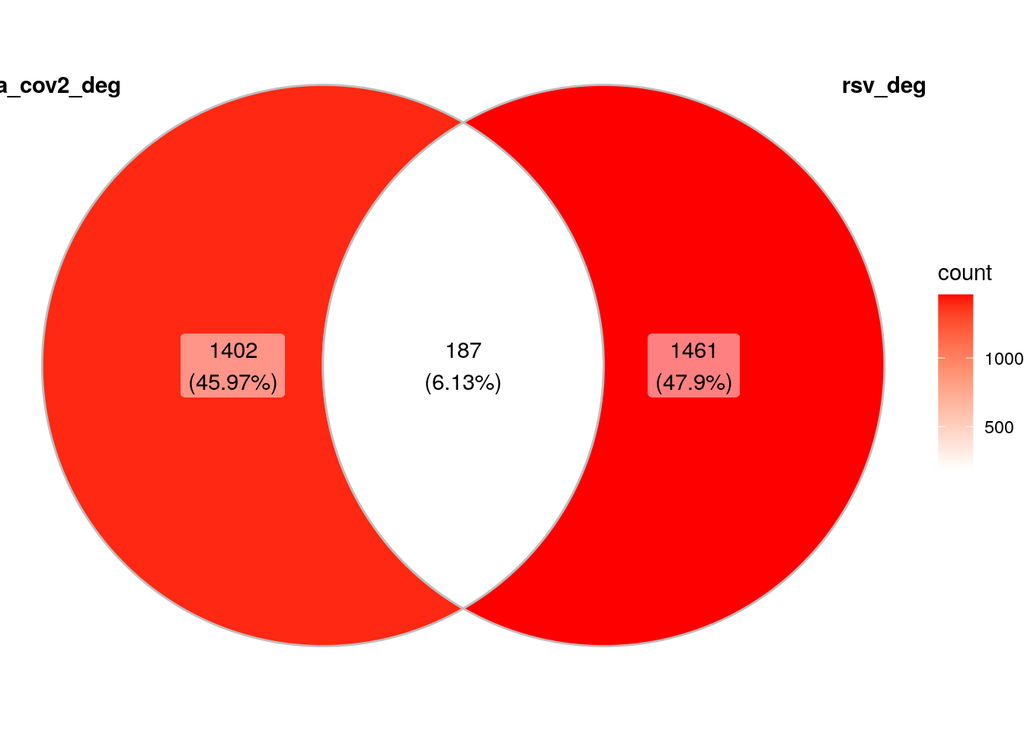

```r
sars_cov2_rsv_venn_list <-
  list(sara_cov2_deg = sars_cov2_result_deg$external_gene_name,
     rsv_deg = rsv_result_deg$external_gene_name)

ggVennDiagram(sars_cov2_rsv_venn_list)
```

Heatmap with all significant DEGs

```r
matrix_vst_sars_cov2_heatmap_table <-
  assay(sars_cov2_vst) %>%
  {.[sars_cov2_result_filtered$rowname,]} ## extracting only significant DEGs

head(matrix_vst_sars_cov2_heatmap_table)
```

```
##                 GSM4462342 GSM4462343 GSM4462344 GSM4462345 GSM4462346
## ENSG00000001630   9.019668   9.008340   8.886995   8.001579   7.896532
## ENSG00000003400   5.678688   6.099453   5.777449   6.743630   7.042903
## ENSG00000003989   7.211141   6.754011   6.973520   8.354599   7.987662
## ENSG00000005007   7.969489   7.988027   8.000956   8.820829   8.692932
## ENSG00000005483   8.259521   7.487811   7.763580   9.371661   9.252322
## ENSG00000005884  11.438761  11.734595  11.803722  10.568180  10.470853
##                 GSM4462347
## ENSG00000001630   8.148371
## ENSG00000003400   7.205178
## ENSG00000003989   8.204534
## ENSG00000005007   9.353716
## ENSG00000005483   8.775661
## ENSG00000005884  10.350786
```

```r
matrix_vst_rsv_heatmap_table <-
  assay(rsv_vst) %>%
  {.[rsv_result_filtered$rowname,]} ## extracting only significant DEGs

head(matrix_vst_rsv_heatmap_table)
```

```
##                 GSM4462354 GSM4462355 GSM4462356 GSM4462357 GSM4462358
## ENSG00000002549   7.600355   8.183451   8.267655  10.332309  10.721970
## ENSG00000003400   6.678832   6.188300   6.397919   8.273460   7.887506
## ENSG00000004399  10.540602   8.443434   9.086894   7.909795   8.067124
## ENSG00000004468   5.847891   6.911091   7.286053   8.308434   8.790684
## ENSG00000004660   8.298739   7.640191   7.695439   6.475677   6.385533
## ENSG00000004848   3.908918   8.549976   4.843161   3.538933   3.826378
##                 GSM4462359
## ENSG00000002549  10.414767
## ENSG00000003400   7.606416
## ENSG00000004399   7.688399
## ENSG00000004468   8.468199
## ENSG00000004660   6.290135
## ENSG00000004848   3.686266
```

Replacing ensemble_id with external gene name for heatmap only for DEGs

```r
matrix_vst_sars_cov2_heatmap_gene_name_table <- ## replacing row names to genes for pheatmap
  matrix_vst_sars_cov2_heatmap_table %>%
  as.data.frame() %>%
  rownames_to_column("ensg_name") %>%
  as_tibble(.) %>%
  inner_join(., sars_cov2_result_deg[, c("rowname", "external_gene_name")],
             by = c("ensg_name"= "rowname")) %>%
  dplyr::select(external_gene_name, 2:7) %>%
  column_to_rownames("external_gene_name") %>%
  as.matrix()

head(matrix_vst_sars_cov2_heatmap_gene_name_table)
```

```
##         GSM4462342 GSM4462343 GSM4462344 GSM4462345 GSM4462346 GSM4462347
## CYP51A1   9.019668   9.008340   8.886995   8.001579   7.896532   8.148371
## CASP10    5.678688   6.099453   5.777449   6.743630   7.042903   7.205178
## SLC7A2    7.211141   6.754011   6.973520   8.354599   7.987662   8.204534
## UPF1      7.969489   7.988027   8.000956   8.820829   8.692932   9.353716
## KMT2E     8.259521   7.487811   7.763580   9.371661   9.252322   8.775661
## ITGA3    11.438761  11.734595  11.803722  10.568180  10.470853  10.350786
```

```r
matrix_vst_rsv_heatmap_gene_name_table <- ## replacing row names to genes for pheatmap
  matrix_vst_rsv_heatmap_table %>%
  as.data.frame() %>%
  rownames_to_column("ensg_name") %>%
  as_tibble(.) %>%
  inner_join(., rsv_result_deg[, c("rowname", "external_gene_name")],
             by = c("ensg_name"= "rowname")) %>%
  dplyr::select(external_gene_name, 2:7) %>%
  column_to_rownames("external_gene_name") %>%
  as.matrix()

head(matrix_vst_rsv_heatmap_gene_name_table)
```

```
##        GSM4462354 GSM4462355 GSM4462356 GSM4462357 GSM4462358 GSM4462359
## LAP3     7.600355   8.183451   8.267655  10.332309  10.721970  10.414767
## CASP10   6.678832   6.188300   6.397919   8.273460   7.887506   7.606416
## PLXND1  10.540602   8.443434   9.086894   7.909795   8.067124   7.688399
## CD38     5.847891   6.911091   7.286053   8.308434   8.790684   8.468199
## CAMKK1   8.298739   7.640191   7.695439   6.475677   6.385533   6.290135
## ARX      3.908918   8.549976   4.843161   3.538933   3.826378   3.686266
```

Creating dataframes for annotation bar

```r
sars_cov2_annotation <-
  data.frame(conditions = metadata_a549_cell_sars_cov2$conditions)

row.names(sars_cov2_annotation) <- colnames(matrix_vst_sars_cov2_heatmap_gene_name_table)


rsv_annotation <-
  data.frame(conditions = metadata_a549_cell_rsv$conditions)

row.names(rsv_annotation) <- colnames(matrix_vst_rsv_heatmap_gene_name_table)
```

pheatmap for all significant DEGs

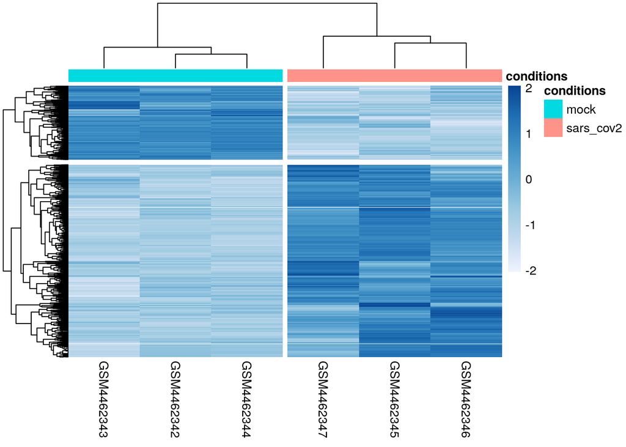

```r
pheatmap(matrix_vst_sars_cov2_heatmap_gene_name_table,
         fontsize_row = 4, scale = "row",
         color = colorRampPalette(brewer.pal(n = 7, name = "Blues"))(100),
         cutree_cols = 2, cutree_rows = 2,
         annotation_col = sars_cov2_annotation,
         show_rownames = F,
         legend = T)
```

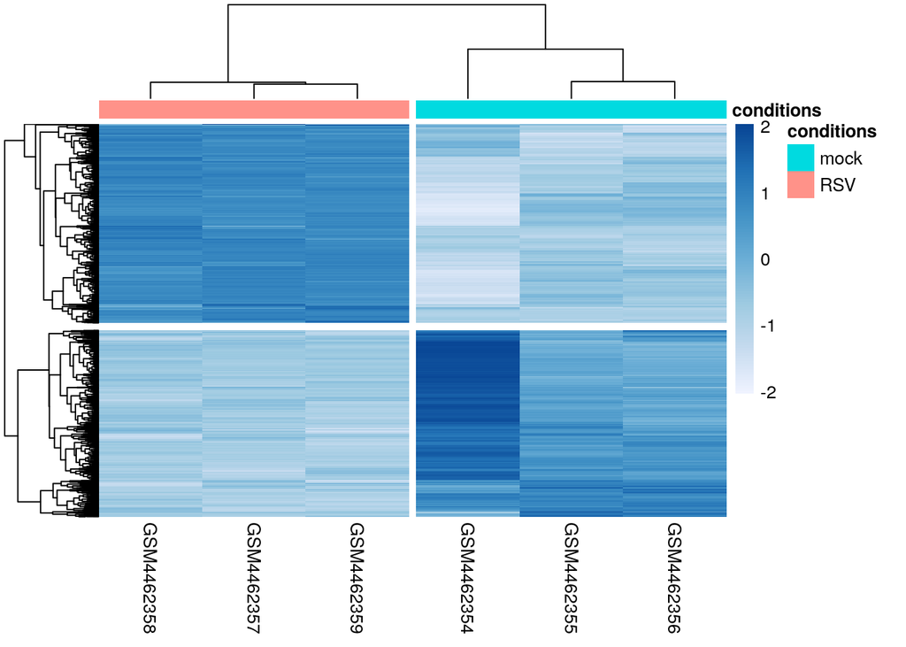

```r
pheatmap(matrix_vst_rsv_heatmap_gene_name_table,
         fontsize_row = 4, scale = "row",
         color = colorRampPalette(brewer.pal(n = 7, name = "Blues"))(100),
         cutree_cols = 2, cutree_rows = 2,
         annotation_col = rsv_annotation,
         show_rownames = F,
         legend = T)
```

Number of genes up and down regulated in RSV vs sars_cov2

```r
sars_cov2_up_down_regulated <-
  sars_cov2_result_deg %>%
  dplyr::select(rowname, log2FoldChange) %>%
  dplyr::mutate(fold_change = ifelse(.$log2FoldChange > 1, "Up_regulated", "Down_regulated")) %>%
  group_by(fold_change) %>%
  tally()

sars_cov2_up_down_regulated
```

```
## # A tibble: 2 x 2
##   fold_change        n
##   <chr>          <int>
## 1 Down_regulated   441
## 2 Up_regulated    1148
```

```r
rsv_up_down_regulated <-
  rsv_result_deg %>%
  dplyr::select(rowname, log2FoldChange) %>%
  dplyr::mutate(fold_change = ifelse(.$log2FoldChange > 1, "Up_regulated", "Down_regulated")) %>%
  group_by(fold_change) %>%
  tally()

rsv_up_down_regulated
```

```
## # A tibble: 2 x 2
##   fold_change        n
##   <chr>          <int>
## 1 Down_regulated   798
## 2 Up_regulated     850
```

Lot of genes upregulated in sars_cov2 compared to RSV infection

Top 10 up and down regulated genes in sars_cov2 infection

```r
sars_cov2_up_regulated_regulated <-
  sars_cov2_result_deg %>%
  dplyr::select(rowname, log2FoldChange, pvalue, external_gene_name) %>%
  dplyr::mutate(fold_change = ifelse(.$log2FoldChange > 1, "Up_regulated", "Down_regulated")) %>%
  arrange(desc(log2FoldChange)) %>%
  slice(1:10) %>%
  dplyr::select(external_gene_name, log2FoldChange, pvalue)

sars_cov2_up_regulated_regulated
```

```
## # A tibble: 10 x 3
##    external_gene_name log2FoldChange   pvalue
##    <chr>                       <dbl>    <dbl>
##  1 EGR1                         9.50 8.02e-71
##  2 RNU5A-1                      9.18 4.32e-13
##  3 AC007405.2                   8.84 2.30e- 3
##  4 AF228730.5                   8.73 7.41e- 6
##  5 GPR142                       8.61 1.46e-10
##  6 TNF                          7.59 1.10e- 7
##  7 PPP4R4                       7.55 1.36e- 7
##  8 SELE                         7.53 1.75e- 7
##  9 CD300LB                      7.32 1.66e- 7
## 10 LTB                          7.12 2.17e-11
```

```r
sars_cov2_down_regulated_regulated <-
  sars_cov2_result_deg %>%
  dplyr::select(rowname, log2FoldChange, pvalue, external_gene_name) %>%
  dplyr::mutate(fold_change = ifelse(.$log2FoldChange > 1, "Up_regulated", "Down_regulated")) %>%
  arrange(log2FoldChange) %>%
  slice(1:10) %>%
  dplyr::select(external_gene_name, log2FoldChange, pvalue)

sars_cov2_down_regulated_regulated
```

```
## # A tibble: 10 x 3
##    external_gene_name log2FoldChange      pvalue
##    <chr>                       <dbl>       <dbl>
##  1 GRIN2B                      -7.69 0.000000795
##  2 LINC00649                   -6.20 0.00000829
##  3 CDH16                       -5.64 0.0000506
##  4 AL160269.1                  -5.53 0.000121
##  5 AL136295.1                  -5.43 0.000262
##  6 TNK2-AS1                    -5.23 0.00401
##  7 AC004982.2                  -5.11 0.0000972
##  8 NUDT4B                      -4.94 0.00177
##  9 AC010655.2                  -4.90 0.00197
## 10 NPHP3-ACAD11                -4.85 0.00163
```

Top 10 up and down regulated genes in RSV infection

```r
rsv_up_regulated_regulated <-
  rsv_result_deg %>%
  dplyr::select(rowname, log2FoldChange, pvalue, external_gene_name) %>%
  dplyr::mutate(fold_change = ifelse(.$log2FoldChange > 1, "Up_regulated", "Down_regulated")) %>%
  arrange(desc(log2FoldChange)) %>%
  slice(1:10) %>%
  dplyr::select(external_gene_name, log2FoldChange, pvalue)

rsv_up_regulated_regulated
```

```
## # A tibble: 10 x 3
##    external_gene_name log2FoldChange   pvalue
##    <chr>                       <dbl>    <dbl>
##  1 IFNL1                       10.1  4.71e-17
##  2 CCL3                         8.85 5.54e-12
##  3 RSAD2                        8.74 2.03e-16
##  4 GBP5                         8.68 9.19e-12
##  5 IFI44                        8.39 2.68e-15
##  6 IFNL2                        8.36 7.41e-11
##  7 CXCL11                       8.10 2.18e-10
##  8 LINC00649                    8.06 3.05e- 3
##  9 OASL                         7.99 1.41e-61
## 10 IFNB1                        7.98 6.79e-10
```

```r
rsv_down_regulated_regulated <-
  rsv_result_deg %>%
  dplyr::select(rowname, log2FoldChange, pvalue, external_gene_name) %>%
  dplyr::mutate(fold_change = ifelse(.$log2FoldChange > 1, "Up_regulated", "Down_regulated")) %>%
  arrange(log2FoldChange) %>%
  slice(1:10) %>%
  dplyr::select(external_gene_name, log2FoldChange, pvalue)

  rsv_down_regulated_regulated
```

```
## # A tibble: 10 x 3
##    external_gene_name log2FoldChange   pvalue
##    <chr>                       <dbl>    <dbl>
##  1 SMIM11B                     -7.81 8.63e- 7
##  2 SPDEF                       -7.65 1.22e-17
##  3 SFT2D3                      -7.44 3.70e-11
##  4 VIL1                        -7.08 9.91e- 8
##  5 KRT4                        -6.87 6.25e- 9
##  6 ADH1C                       -6.40 4.67e- 5
##  7 AL589182.1                  -6.40 5.81e- 6
##  8 PACSIN1                     -6.38 2.45e- 5
##  9 MYO1A                       -6.27 1.61e-11
## 10 GJB1                        -6.19 2.55e- 4
```

## Cluster profiling

For go enrichment and kegg enrichment we need entrez id not ensemble id

sars_cov2 entrez id

```r
entrez_annotation_sars_cov2_result <-
  getBM(attributes = c("entrezgene_id", "external_gene_name", "description"),
        filters = c("ensembl_gene_id"),
        values = sars_cov2_result_deg$rowname, ## only differtial expressed genes- significant
        mart = ensembl_100_human)

head(entrez_annotation_sars_cov2_result)
```

```
##   entrezgene_id external_gene_name
## 1          1595            CYP51A1
## 2           843             CASP10
## 3          6542             SLC7A2
## 4          5976               UPF1
## 5         55904              KMT2E
## 6          3675              ITGA3
##                                                                         description
## 1 cytochrome P450 family 51 subfamily A member 1 [Source:HGNC Symbol;Acc:HGNC:2649]
## 2                                     caspase 10 [Source:HGNC Symbol;Acc:HGNC:1500]
## 3              solute carrier family 7 member 2 [Source:HGNC Symbol;Acc:HGNC:11060]
## 4                   UPF1 RNA helicase and ATPase [Source:HGNC Symbol;Acc:HGNC:9962]
## 5                   lysine methyltransferase 2E [Source:HGNC Symbol;Acc:HGNC:18541]
## 6                       integrin subunit alpha 3 [Source:HGNC Symbol;Acc:HGNC:6139]
```

```r
vector_entrez_annotation_sars_cov2_result <-  ## go enrrichment takes vector
  entrez_annotation_sars_cov2_result$entrezgene_id

head(vector_entrez_annotation_sars_cov2_result)
```

```
## [1]  1595   843  6542  5976 55904  3675
```

RSV entrez id

```r
entrez_annotation_rsv_result <-
  getBM(attributes = c("entrezgene_id", "external_gene_name", "description"),
        filters = c("ensembl_gene_id"),
        values = rsv_result_deg$rowname, ## only differtial expressed genes- significant
        mart = ensembl_100_human)

head(entrez_annotation_rsv_result)
```

```
##   entrezgene_id external_gene_name
## 1         51056               LAP3
## 2           843             CASP10
## 3         23129             PLXND1
## 4           952               CD38
## 5         84254             CAMKK1
## 6        170302                ARX
##                                                                               description
## 1                            leucine aminopeptidase 3 [Source:HGNC Symbol;Acc:HGNC:18449]
## 2                                           caspase 10 [Source:HGNC Symbol;Acc:HGNC:1500]
## 3                                            plexin D1 [Source:HGNC Symbol;Acc:HGNC:9107]
## 4                                        CD38 molecule [Source:HGNC Symbol;Acc:HGNC:1667]
## 5 calcium/calmodulin dependent protein kinase kinase 1 [Source:HGNC Symbol;Acc:HGNC:1469]
## 6                         aristaless related homeobox [Source:HGNC Symbol;Acc:HGNC:18060]
```

```r
vector_entrez_annotation_rsv_result <-  ## go enrrichment takes vector
  entrez_annotation_rsv_result$entrezgene_id

head(vector_entrez_annotation_rsv_result)
```

```
## [1]  51056    843  23129    952  84254 170302
```

sars_cov2 universe id

```r
universe_entrez_annotation_sars_cov2_result <-  ## for universe argument for go or kegg enrichment
  getBM(attributes = c("entrezgene_id", "external_gene_name", "description"),
        filters = c("ensembl_gene_id"),
        values = sars_cov2_annotation_result$rowname, ## here we are using all gens (similarly used in valcano plot) ## basic concept is for fisher exact test you need pool and here pool is all genes
        mart = ensembl_100_human)

head(universe_entrez_annotation_sars_cov2_result)
```

```
##   entrezgene_id external_gene_name
## 1          7105             TSPAN6
## 2          8813               DPM1
## 3         57147              SCYL3
## 4         55732           C1orf112
## 5          3075                CFH
## 6          2519              FUCA2
##                                                                                      description
## 1                                              tetraspanin 6 [Source:HGNC Symbol;Acc:HGNC:11858]
## 2 dolichyl-phosphate mannosyltransferase subunit 1, catalytic [Source:HGNC Symbol;Acc:HGNC:3005]
## 3                                   SCY1 like pseudokinase 3 [Source:HGNC Symbol;Acc:HGNC:19285]
## 4                        chromosome 1 open reading frame 112 [Source:HGNC Symbol;Acc:HGNC:25565]
## 5                                         complement factor H [Source:HGNC Symbol;Acc:HGNC:4883]
## 6                                        alpha-L-fucosidase 2 [Source:HGNC Symbol;Acc:HGNC:4008]
```

```r
universe_vector_entrez_annotation_sars_cov2_result <-  ## go enrrichment takes vector
  as.character(universe_entrez_annotation_sars_cov2_result$entrezgene_id) ## should be a character

class(universe_vector_entrez_annotation_sars_cov2_result)
```

```
## [1] "character"
```

RSV universe id

```r
universe_entrez_annotation_rsv_result <-  ## for universe argument for go or kegg enrichment
  getBM(attributes = c("entrezgene_id", "external_gene_name", "description"),
        filters = c("ensembl_gene_id"),
        values = rsv_annotation_result$rowname, ## here we are using all gens (similarly used in valcano plot) ## basic concept is for fisher exact test you need pool and here pool is all genes
        mart = ensembl_100_human)

head(universe_entrez_annotation_rsv_result)
```

```
##   entrezgene_id external_gene_name
## 1          7105             TSPAN6
## 2          8813               DPM1
## 3         57147              SCYL3
## 4         55732           C1orf112
## 5          3075                CFH
## 6          2519              FUCA2
##                                                                                      description
## 1                                              tetraspanin 6 [Source:HGNC Symbol;Acc:HGNC:11858]
## 2 dolichyl-phosphate mannosyltransferase subunit 1, catalytic [Source:HGNC Symbol;Acc:HGNC:3005]
## 3                                   SCY1 like pseudokinase 3 [Source:HGNC Symbol;Acc:HGNC:19285]
## 4                        chromosome 1 open reading frame 112 [Source:HGNC Symbol;Acc:HGNC:25565]
## 5                                         complement factor H [Source:HGNC Symbol;Acc:HGNC:4883]
## 6                                        alpha-L-fucosidase 2 [Source:HGNC Symbol;Acc:HGNC:4008]
```